# 2-2

Smallmin

2022-07-10

## 2.2 Discrete Random Variables

**Definition**: If X is a discrete random variable, its **probability mass function (pmf)** is f(x) ≡ P(X = x), for all x. Note that if X is discrete, then $0 \leq f(x) \leq 1$, for all $x$, and $\sum_{x} f(x)=1$

**Example**: Flip two coins. Let X be the number of heads.
$$f(x)=\left\{\begin{array}{cl}
1 / 4 & \text { if } x=0 \text { or } 2 \\
1 / 2 & \text { if } x=1 \\
0 & \text { otherwise }
\end{array}\right.$$
**Example/Definition**: Suppose X can equal 1,2,…,n, each with probability $1 / n \text {, i.e., } f(i)=1 / n, i=1,2, \ldots, n \text {. }$ Then we say that X has the **discrete** **uniform**{1,2,…,n} **distribution**.

**Example**: A discrete RV can have any values. For instance, let X denote the possible profits from an inventory policy, where $f$(−5.1) = 0.2 (lose money), $f$(1.3) = 0.5 (break even), and $f$(11) = 0.3 (big bucks).

**Example/Definition**: Let X denote the number of “successes” from n independent trials such that the probability of success at each trial is p (0 ≤ p ≤ 1). Then X has the **binomial distribution**, with parameters n and p. The trials are referred to as **Bernoulli trials**, named after Jakob Bernoulli (1655–1705).

**Notation**: X ~ Bin(n, p).

**Example**: Roll a die three independent times. Find P(exactly two 6’s). We interpret each toss as a Bernoulli trial in which a 6 is a success, and anything else (1,2,3,4,5) is a failure. All three trials are independent, and P(success) = 1/6 doesn’t change from trial to trial.

Let X = the number of 6’s. Then X ~ Bin(3, $\frac{1}{6}$ ).

**Example** (cont’d): Back to the dice example, where X ~ Bin(3, $\frac{1}{6}$), and we want $P(exactly two 6’s)$. We have $n = 3, k = 2, p = 1/6, and q = 5/6.$ Then
$$\mathrm{P}(X=2)=\left(\begin{array}{l}
3 \\
2
\end{array}\right)\left(\frac{1}{6}\right)^{2}\left(\frac{5}{6}\right)^{1}=\frac{15}{216}$$
In fact, we can get the entire pmf,
$$\begin{array}{c|cccc}
k & 0 & 1 & 2 & 3 \\
\hline \mathrm{P}(X=k) & \frac{125}{216} & \frac{75}{216} &
\frac{15}{216} & \frac{1}{216}
\end{array}$$
Example: Roll two dice and get the sum. Repeat this experiment 12 times. Find P(Sum will be 7 or 11 exactly three times). Let X = the number of times we get 7 or 11. Then

$P(7$ or $11) = P(7) + P(11) = \frac{6}{36} + \frac{2}{36} = \frac{2}{9}$

So X ~ Bin(12, 2/9), and then
$$\mathrm{P}(X=3)=\left(\begin{array}{c}
12 \\
3
\end{array}\right)\left(\frac{2}{9}\right)^{3}\left(\frac{7}{9}\right)^{9}$$
**Definition**: If $\mathrm{P}(X=k)=e^{-\lambda} \lambda^{k} / k !, k=0,1,2, \ldots, \text { and }\lambda>0$ we say that X has the Poisson distribution with parameter $\lambda$, so named after Siméon Denis Poisson (1781–1840).

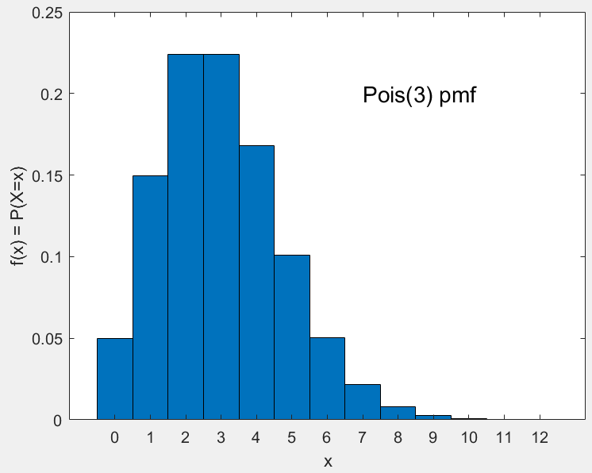